# Project Applied Statistics - Saravanan Janarthanan

## Part A

**Question 1: 1A.** Refer above table and find the joint probability of the people who planned to purchase and actually placed an order.

**Ans.** Joint Probability of the people who planned to purchase against people whom actually placed the order

400 planned to purchase and placed an order for Product A out of 2000 people sampled

Joint Probability is p('People Purchased' AND 'Total People'). The probability of event A and event B occurring

```python
# Load libraries
import numpy  as np
import pandas as pd
import scipy.stats as stats
import matplotlib.pyplot as plt
```

```python
class color:
   BOLD = '\033[1m'
   END = '\033[0m'

# ppl_Placed_Order - People placed order of Product A
ppl_Placed_Order = 400

# tot_Ppl_Sampled - Total people sampled for planned purchase Product A
tot_Ppl_Sampled  = 2000

# jnt_Prob Probability of people who purchased against a probable people planned.
jnt_Prob         =  ppl_Placed_Order / tot_Ppl_Sampled

print( color.BOLD + 'Answer 1A'+color.END+': Joint Probability of the people who planned to purchase Product A vs people whom actually placed the order is {:.2f}% ({:.5f})'.format( jnt_Prob*100, jnt_Prob )  )
```

```
Answer 1A: Joint Probability of the people who planned to purchase Product A vs people whom actually placed the order is 20.00% (0.20000)
```

**Question 1: 1B.** Refer to the above table and find the joint probability of the people who planned to purchase and actually placed an order, given that people planned to purchase

**Ans.** Coditional Probability of People planned and purchased Product A against the probability of people planned to purchase

Probability of People planned and purchased Product A : P(People planned and purchased Product A) = 400 / 2000

Probability of Planned to Purchase : P(Planned to Purchase ) = 500 / 2000

People planned and purchased = 400

Planned to purchase = 500

Total sampled = 2000

Conditional probability = P(People planned and purchased Product A) / P(Planned to Purchase )

```python
# ppl_PlndPurc -  people planned purchase Product A
ppl_PlndPurc  = 500

#Conditional Probability is Probability of People planned and purchased by Probability of people planned to purchase
cond_Prob     = ( ppl_Placed_Order / tot_Ppl_Sampled ) / ( ppl_PlndPurc / tot_Ppl_Sampled )


print( color.BOLD +'Answer 1B '+color.END+': joint probability of the people who planned to purchase and actually placed an order, given that people planned to purchase is {:.2f}% ({:.5f}) '.format( cond_Prob*100,  cond_Prob ) )
```

```
Answer 1B : joint probability of the people who planned to purchase and actually placed an order, given that people planned to purchase is 80.00% (0.80000)
```

**Question 2** An electrical manufacturing company conducts quality checks at specified periods on the products it manufactures. Historically, the failure rate for the manufactured item is 5%. Suppose a random sample of 10 manufactured items is selected.

**Q 2.A** Probability that none of the items are defective?

**Ans** Binomial distribution is used in quality control and quality control and quality assurance hence can be used for above defective analysis Since 10 items are selected, the defective number probability varies from 0 to 10 , 11 possibilities or quantiles (**samp_rng**) using python binomal function probability mass function to ascertain the distribution by passing all possible values of defective rate **def_rate** i.e 5% or 0.05 for a range 0 to sample number **samp_num** i.e 10. None of them defective lies in the 1st position of the distribution or 0 index

```python
# defective or failure rate
def_rate = 0.05

# sample numbers
samp_num = 10 #

# possible values or array of quantiles of definite
samp_rng = np.arange( 0,11 )

#binomial distribution of possible defective rate
bin_posb_val = stats.binom.pmf( samp_rng, samp_num, def_rate )

print( color.BOLD +'Answer 2B '+color.END+': Probability that none of the items are defective is {:.2f}% ({:.5f})'.format( bin_posb_val[0]*100, bin_posb_val[0] ) )
```

```
Answer 2B : Probability that none of the items are defective is 59.87% (0.59874)
```

**Q 2.B** Probability that exactly one of the items is defective?</br>

**Ans** Probablity of exactly one of the items is defective is lies in the second position of the binomial distribution or 1 of the index

```python
print( color.BOLD +'Answer 2B'+color.END+': Probability that exactly one of the items defective is {:.2f}% ({:.5f})'.format( bin_posb_val[1]*100, bin_posb_val[1] ) )
```

```
Answer 2B: Probability that exactly one of the items defective is 31.51% (0.31512)
```

**Q 2.C.** Probability that two or fewer of the items are defective?

**Ans** The probability of two or lesser items being defective is the cumulative of the defective probability distribution from 0 to 2. Using the Cumulative density function the cumulative distribution for 0 to 2 can be arrived or use the sum of the probabilities of 0, 1 & 2 from probability mass function.

```python
none_deft = bin_posb_val[0]+ bin_posb_val[1] + bin_posb_val[2]
print( color.BOLD +'Answer 2C'+color.END+': Probability that none of the items are defective is {:.2f}% ({:.5f})'.format( none_deft*100, none_deft ) )
```

```
Answer 2C: Probability that none of the items are defective is 98.85% (0.98850)
```

```python
#Cumulative density function
cum_den_val = stats.binom.cdf( samp_rng, samp_num, def_rate )
print( color.BOLD +'Answer 2C'+color.END+': Probability that none of the items are defective is {:.2f}% ({:.5f})'.format( cum_den_val[2]*100, cum_den_val[2] ) )
```

```
Answer 2C: Probability that none of the items are defective is 98.85% (0.98850)
```

**Q 2.D.** Probability that three or more of the items are defective ?

**Ans.** Simillar to 2C solution the possible values form three or more items being defecive is sum of the probabilites from 3 to 10 or deducting the cumulative probability of upto 2 items from max cumulative probability or deducting the cumulative probability of upto 2 items from 1 which is the sum of the all the probabilities from the possible probabaility distribution

```python
# sum of the probabilites from 3 to 10
sum_3_to_10 = bin_posb_val[3]+ bin_posb_val[4] + bin_posb_val[5]+bin_posb_val[6]+ bin_posb_val[7] + bin_posb_val[8]+bin_posb_val[9]+ bin_posb_val[10]
print( color.BOLD +'Answer 2D'+color.END+': Probability that none of the items are defective is {:.2f}% ({:.5f})'.format( sum_3_to_10*100, sum_3_to_10 ) )
```

```
Answer 2D: Probability that none of the items are defective is 1.15% (0.01150)
```

```python
#deducting the cumulative probability of upto 2 items from max cumulative probability
cum_prob1 = cum_den_val[10] - cum_den_val[2]
print( color.BOLD +'Answer 2D'+color.END+': Probability that none of the items are defective is {:.2f}% ({:.5f})'.format( cum_prob1*100, cum_prob1 ) )
```

```
Answer 2D: Probability that none of the items are defective is 1.15% (0.01150)
```

```python
#deducting the cumulative probability of upto 2 items from 1 i.e from sum of the all the probabilities
cum_prob2 = 1 - cum_den_val[2]
print( color.BOLD +'Answer 2D'+color.END+': Probability that none of the items are defective is {:.2f}% ({:.5f})'.format( cum_prob2*100, cum_prob2 ) )
```

```
Answer 2D: Probability that none of the items are defective is 1.15% (0.01150)
```

**Question 3** A car salesman sells on an average 3 cars per week</br>

**Q 3.A.** What is Probability that in a given week he will sell some cars?

**Ans.** The mean or average the car salesman sells cars is 3 per week to identify the probability of car sales for a given week that is a fixed interval of time , without fixed number of distributions use poisson distribution

mean or average (λ) is 3 (**pois_lambda**)

max numbers of cars the salesman could have sold is assumed as 10 (in a week might have sold nothing upto 10 ) Possibility ranges from 0 to 10 (**sale_range**)

The probability that salesman will sell some cars is from 1 car sales and above, i.e summing up all the probabilities from 1 to max car sales

```python
# mean or average (λ) is 3
pois_lambda  = 3

#max numbers of cars the salesman could have sold
max_car_sale = 10

#Possibility ranges
sale_range   = np.arange( 0, max_car_sale+1 )

#poisson distribution
cuml_poisson_dist = stats.poisson.cdf( sale_range , pois_lambda )

#The probability that salesman will sell some cars in a given week 1- cumulative of none i.e 1st distribution of probability
cum_poiss_some = 1 - cuml_poisson_dist[0]
print(color.BOLD +'Answer 3A '+color.END+': Probability that salesman will sell some cars in a given week is {:.2f}% ({:.5f})'.format( cum_poiss_some*100, cum_poiss_some ) )
```

```
Answer 3A : Probability that salesman will sell some cars in a given week is 95.02% (0.95021)
```

**3.B.** What is Probability that in a given week he will sell 2 or more but less than 5 cars?

**Ans.** The Probability that in a given week he will sell 2 or more but less than 5 cars is summing up the probabilities selling 2 cars, 3 cars and 4 cars a week

```python
# Use poisson probability mass function
poiss_pmf = stats.poisson.pmf( sale_range , pois_lambda )

car_sale_2_to_4 = poiss_pmf[2]+ poiss_pmf[3]+poiss_pmf[4]
print( color.BOLD +'Answer 3B '+color.END+': Probability that in a given week he will sell 2 or more but less than 5 cars is {:.2f}% ({:.4f}) '.format( car_sale_2_to_4*100,  car_sale_2_to_4 ))
```

```
Answer 3B : Probability that in a given week he will sell 2 or more but less than 5 cars is 61.61% (0.6161)
```

**Q 3.C.** Plot the poisson distribution function for cumulative probability of cars sold per-week vs number of cars sold per week

**Ans.** Using the matplotlib library , the poisson distribution function can be plotted

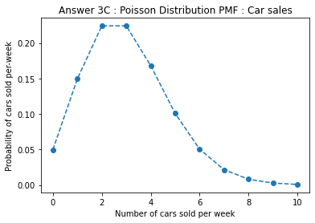

```python
#sb.set(font_scale=1)
# Use pyplot API (alais plt) to plot the poisson distribution function
plt.plot( sale_range ,  poiss_pmf, 'o--' )

#Set the title
plt.title( 'Answer 3C : Poisson Distribution PMF : Car sales' )

#set the y axis on cumulative probabilities of car sold
plt.ylabel( 'Probability of cars sold per-week' )

# Set the X axis label thats is the car sale number range
plt.xlabel( 'Number of cars sold per week' )

f = plt.figure()
f.set_figwidth(6)
f.set_figheight(5)

plt.show( )
```

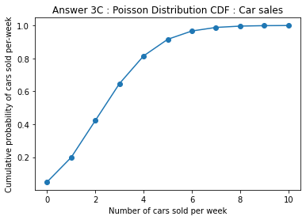

```python
# Use pyplot API (alais plt) to plot the poisson distribution function
plt.plot( sale_range ,  cuml_poisson_dist , 'o-' )

#Set the title
plt.title( 'Answer 3C : Poisson Distribution CDF : Car sales' )

#set the y axis on cumulative probabilities of car sold
plt.ylabel( 'Cumulative probability of cars sold per-week' )

# Set the X axis label thats is the car sale number range
plt.xlabel( 'Number of cars sold per week' )

plt.show( )
```

**Question 4**

Accuracy in understanding orders for a speech based bot at a restaurant is important for the Company X which has designed, marketed and launched the product for a contactless delivery due to the COVID-19 pandemic. Recognition accuracy that measures the percentage of orders that are taken correctly is 86.8%. Suppose that you place an order with the bot and two friends of yours independently place orders with the same bot. Answer the following questions.

**Q 4.A.**

What is the probability that all three orders will be recognised correctly?

Since the outcome has two possibilities either all 3 orders are recognized by the bot or not , using binomial distribution identify the probabiity of success of 3 orders going through with a sucess rate of 86.8% all three orders going through is the 4th outcome out of total 4 outcomes

1st outcome - none of the three orders getting through

2nd outcome - 1 out of 3 orders getting through

3rd outcome - 2 out of 3 orders getting through

4th outcome - 3 out of 3 orders getting through

```python
# Sucess rate
sux_rt = 0.868

# number of trials
trial_num = 3

# possible outcomes
pos_outcm = np.arange( 0,trial_num+1 )

binom_sucss = stats.binom.pmf( pos_outcm, trial_num, sux_rt )

print( color.BOLD +'Answer 4A'+color.END+': Probability that all three orders will be recognised correctly is {:.2f}% ({:.5f}) '.format( binom_sucss[3]*100,  binom_sucss[3] ) )
```

```
Answer 4A: Probability that all three orders will be recognised correctly is 65.40% (0.65397)
```

**Q 4.B.** What is the probability that none of the three orders will be recognised correctly?

**Ans** The probability that none of the three orders will be recognised correctly is 1st outcome - none of the three orders getting through

```python
print( color.BOLD +'Answer 4B'+color.END+': Probability that none of the three orders will be recognised correctly is {:.2f}% ({:.5f}) '.format( binom_sucss[0]*100,  binom_sucss[0] ) )
```

```
Answer 4B: Probability that none of the three orders will be recognised correctly is 0.23% (0.00230)
```

**Q 4.C.** What is the probability that at least two of the three orders will be recognised correctly?

**Ans.** The probability that at least two of the three orders will be recognised correctly is sum of 3rd outcome and 4th outcome, the success ranging between 2 to 3 orders going through

```python
# sum of probabilities of 2 order and 3 order placed sucessfully
prob_1_to_2_sucss = binom_sucss[2] + binom_sucss[3]
print( color.BOLD +'Answer 4B'+color.END+': Probability that at least two of the three orders will be recognised correctly {:.2f}% ({:.5f}) '.format( prob_1_to_2_sucss*100,  prob_1_to_2_sucss ) )
```

```
Answer 4B: Probability that at least two of the three orders will be recognised correctly 95.23% (0.95233)
```

</br>

**Q 5** Explain 1 real life industry scenario (other than the ones mentioned above) where you can use the concepts learnt in this module of Applied Statistics to get data driven business solution.

**Ans** Probability distributions are used in medical research studies.

**Binomial distribution** can or is being used to determine the medical trial outcomes whether it is accepted or rejected since It is a probability model for a discrete outcome it gives x sucesses out of y trials of any event

**Poisson distribution** describes the behaviour of rare events or model randon events</br> such as

- guessing the probability of number of patients arriving at an emergency room based on historical average numbers and decide on needed medical personel
- observing incident cases or rare disease in a given population
- likelihood of patients requiring immediate surgery and need of additonal operating room given the number of operating room available

**Normal Distribution** can be used to observe the blood pressure among a sample or population.</br> Using the standard deviation of the sample distribution study the variations in blood pressure measurements, Identify the low pressure or high pressure using the limits of 2 standard deviations or 3 standard deviations

## Part B

**Q 1.** Read the data set, clean the data and prepare final dataset to be used for analysis. </br>2. Perform detailed statistical analysis and EDA using univariate, bi-variate and multivariate EDA techniques to get data driven insights on recommending which teams they can approach which will be a deal win for them. Also as a data and statistics expert you have to develop a detailed performance report using this data.

**Ans 1** Importing the Library - most of them already loaded

```python
import seaborn as sb
import warnings
from PIL import Image
warnings.filterwarnings("ignore")
```

```python
# Read the data file
part_b_data = pd.read_csv('AnalyticsProject\DS_Part2_Basketball.csv')
```

```python
# Print the top 5 records
part_b_data.head()
```

|  | Team | Tournament | Score | PlayedGames | WonGames | DrawnGames | LostGames | BasketScored | BasketGiven | TournamentChampion | Runner-up | TeamLaunch | HighestPositionHeld |
| --- | --- | --- | --- | --- | --- | --- | --- | --- | --- | --- | --- | --- | --- |
| 0 | Team 1 | 86 | 4385 | 2762 | 1647 | 552 | 563 | 5947 | 3140 | 33 | 23 | 1929 | 1 |
| 1 | Team 2 | 86 | 4262 | 2762 | 1581 | 573 | 608 | 5900 | 3114 | 25 | 25 | 1929 | 1 |
| 2 | Team 3 | 80 | 3442 | 2614 | 1241 | 598 | 775 | 4534 | 3309 | 10 | 8 | 1929 | 1 |
| 3 | Team 4 | 82 | 3386 | 2664 | 1187 | 616 | 861 | 4398 | 3469 | 6 | 6 | 1931to32 | 1 |
| 4 | Team 5 | 86 | 3368 | 2762 | 1209 | 633 | 920 | 4631 | 3700 | 8 | 7 | 1929 | 1 |

```python
# Check for Duplicates
dup_data = part_b_data.duplicated()
sum(dup_data)
```

```
0
```

Observation : No Duplicate Record

```python
part_b_data.describe()
```

|  | Tournament | HighestPositionHeld |
| --- | --- | --- |
| count | 61.000000 | 61.000000 |
| mean | 24.000000 | 7.081967 |
| std | 26.827225 | 5.276663 |
| min | 1.000000 | 1.000000 |
| 25% | 4.000000 | 3.000000 |
| 50% | 12.000000 | 6.000000 |
| 75% | 38.000000 | 10.000000 |
| max | 86.000000 | 20.000000 |

Observation : Out of 13 columns only 2 columns has all numeric values

```python
# iterate each row and find the numeric count
part_b_data.apply(lambda s: pd.to_numeric(s, errors='coerce').notnull().sum())
```

```
Team                    0
Tournament             61
Score                  60
PlayedGames            60
WonGames               60
DrawnGames             60
LostGames              60
BasketScored           60
BasketGiven            60
TournamentChampion      9
Runner-up              13
TeamLaunch             10
HighestPositionHeld    61
dtype: int64
```

Observation : Out of 61 rows

- 2 columns has 61 row numeric values
- 7 columns has 60 row numeric values
- 3 columns has 1 to 13 row numeric values
- 1 row has no numeric value

remove the 61 row as it does not have enough values in most of the columns

```python
#identify rows that has most of the no numeric values
rows_to_drop_for_nonnumeric = []

#iterate through the dataframe rows
for row_index, row in part_b_data.iterrows():
    #find the rows that has most of the non-numeric values
    if pd.to_numeric(row, errors='coerce').notnull().sum() < 9:
      # add the row index in the list
      rows_to_drop_for_nonnumeric.append(row_index)

#drop the rows that has most of the non-numeric data
part_b_data.drop(rows_to_drop_for_nonnumeric, 0 , inplace=True)
```

```python
# fill or replace the non numeric values (here "-" value) with zero for TournamentChampion and Runner-up column
part_b_data["TournamentChampion"] = pd.to_numeric(part_b_data['TournamentChampion'], errors='coerce').fillna(0)
part_b_data["Runner-up"] = pd.to_numeric(part_b_data['Runner-up'], errors='coerce').fillna(0)
```

```python
# Cleanup the Team Launch column values to have uniform year value
part_b_data["TeamLaunch"] = part_b_data["TeamLaunch"].astype(str).str[0:4]
```

```python
# convert all the columns to type Integer
part_b_data["Score"]       = part_b_data["Score"].astype(int)
part_b_data["PlayedGames"] = part_b_data["PlayedGames"].astype(int)
part_b_data["WonGames"]    = part_b_data["WonGames"].astype(int)
part_b_data["DrawnGames"]  = part_b_data["DrawnGames"].astype(int)
part_b_data["LostGames"]    = part_b_data["LostGames"].astype(int)
part_b_data["BasketScored"]= part_b_data["BasketScored"].astype(int)
part_b_data["BasketGiven"] = part_b_data["BasketGiven"].astype(int)
part_b_data["TeamLaunch"]  = part_b_data["TeamLaunch"].astype(int)
```

```python
# Create new winning rate and losing rate columns in data frame using the played games, wongames and lost games column values
part_b_data['WinRate'] = part_b_data.apply(lambda row: round(row.WonGames/row.PlayedGames,4), axis=1)
part_b_data['LosingRate'] = part_b_data.apply(lambda row: round(row.LostGames/row.PlayedGames,4), axis=1)
```

```python
part_b_data.describe()
```

|  | Tournament | Score | PlayedGames | WonGames | DrawnGames | LostGames | BasketScored | BasketGiven | TournamentChampion | Runner-up | TeamLaunch | HighestPositionHeld | WinRate | LosingRate |
| --- | --- | --- | --- | --- | --- | --- | --- | --- | --- | --- | --- | --- | --- | --- |
| count | 60.000000 | 60.000000 | 60.000000 | 60.000000 | 60.000000 | 60.000000 | 60.000000 | 60.000000 | 60.00000 | 60.000000 | 60.000000 | 60.000000 | 60.000000 | 60.000000 |
| mean | 24.383333 | 916.450000 | 810.100000 | 309.033333 | 192.083333 | 308.816667 | 1159.350000 | 1159.233333 | 1.45000 | 1.433333 | 1957.950000 | 7.050000 | 0.313647 | 0.449920 |
| std | 26.884620 | 1138.342899 | 877.465393 | 408.481395 | 201.985508 | 294.508639 | 1512.063948 | 1163.946914 | 5.51554 | 4.574679 | 26.646732 | 5.315232 | 0.078314 | 0.084012 |
| min | 1.000000 | 14.000000 | 30.000000 | 5.000000 | 4.000000 | 15.000000 | 34.000000 | 55.000000 | 0.00000 | 0.000000 | 1929.000000 | 1.000000 | 0.166700 | 0.203800 |
| 25% | 4.000000 | 104.250000 | 115.500000 | 34.750000 | 26.250000 | 62.750000 | 154.500000 | 236.000000 | 0.00000 | 0.000000 | 1934.750000 | 3.000000 | 0.276100 | 0.411475 |
| 50% | 12.000000 | 395.500000 | 424.500000 | 124.000000 | 98.500000 | 197.500000 | 444.000000 | 632.500000 | 0.00000 | 0.000000 | 1950.500000 | 6.000000 | 0.304900 | 0.457250 |
| 75% | 39.000000 | 1360.500000 | 1345.500000 | 432.750000 | 331.500000 | 563.500000 | 1669.750000 | 2001.250000 | 0.00000 | 0.000000 | 1977.250000 | 10.000000 | 0.335425 | 0.485425 |
| max | 86.000000 | 4385.000000 | 2762.000000 | 1647.000000 | 633.000000 | 1070.000000 | 5947.000000 | 3889.000000 | 33.00000 | 25.000000 | 2016.000000 | 20.000000 | 0.596300 | 0.700000 |

**Answer 1.** Loading and the Cleanup of data is complete

**Q 2.** Perform detailed statistical analysis and EDA using univariate, bi-variate and multivariate EDA techniques to get data driven insights on recommending which teams they can approach which will be a deal win for them. Also as a data and statistics expert you have to develop a detailed performance report using this data.

**Ans 2**

### Univariate Analysis

Univariate analysis is the analysis of attributes or characteristics of one variable. The main objective of univariate analysis is to describe the data and find the patterns that exist in it

```python
# Consider played games column values for univariate analysis
data_played_games = part_b_data["PlayedGames"]
```

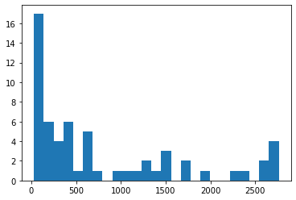

```python
# use histogram for played games data
plt.hist(data_played_games, bins=25)
```

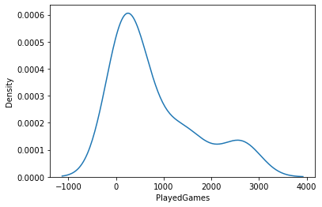

```python
sb.distplot(data_played_games, hist=False)
```

```python
# Consider win rate column values for univariate analysis
data_winrate = part_b_data["WinRate"]
```

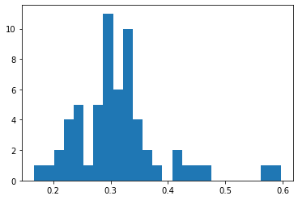

```python
# use histogram for win rate data
plt.hist(data_winrate, bins=25)
```

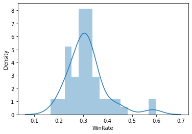

```python
sb.distplot(data_winrate)
```

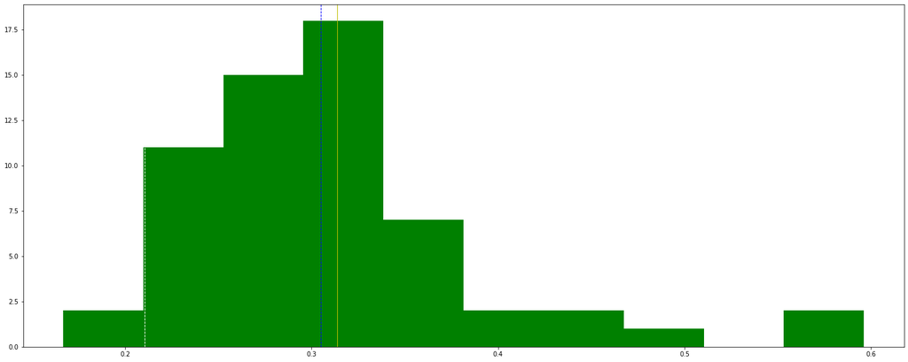

```python
plt.figure(figsize=(25,10))
plt.hist(data_winrate, color='g')
plt.axvline(data_winrate.mean(), color='y', linewidth=1)
plt.axvline(data_winrate.median(), color='b', linestyle='dashed', linewidth=1)
plt.axvline(data_winrate.mode()[0], color='w', linestyle='dashed', linewidth=1)
```

### Bivariate Analysis

In Bivariate analysis we look into relationship between two variables

**Tournament Won**</br> Considering two variables Teamname and tournament won, filtering the records of team that has won atleast one tournament and plotting a bar chart.Tournament played is used as a comparision

```python
# filter the rows data that has a tournament won or championship value above 0
data_trnmt_won = part_b_data[ part_b_data [ 'TournamentChampion'] > 0 ]
```

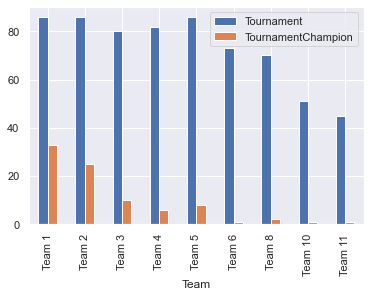

```python
#plotting the graph
sb.set(font_scale=1)
data_trnmt_won.plot(x="Team", y=["Tournament", "TournamentChampion"],  kind="bar")
```

- Team 1 has won more tournaments compared to Team 2 and Team 5

**Tournament Runeer-up**

Considering two variables Teamname and runner-up, filtering the records of team that has been runnerup atleast one tournament and plotting a bar chart. Tournament played is used as a comparision

```python
# filter the rows data that has a runner-up value above 0
data_trnmt_runrup = part_b_data[ part_b_data [ 'Runner-up'] > 0 ]
```

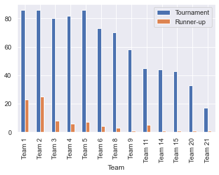

```python
#plotting the graph
data_trnmt_runrup.plot(x="Team", y=["Tournament", "Runner-up"],  kind="bar")
```

- Team 2 has been runnerup more times than Team 1 and Team 5

**Winning rate**

Considering two variables Teamname and winning rate, filtering the records of team that has a winnng rate above 40% and plotting a bar chart.

```python
data_winrate = part_b_data[ part_b_data [ 'WinRate'] > 0.4 ]
```

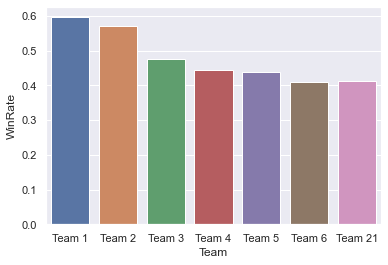

```python
new_plt = sb.barplot(x="Team", y="WinRate",  data=data_winrate)
```

- Team 1 has a higher winning streak

**Basket Scored**

Considering two variables Teamname and Basket Scored, filtering the records of team that has more baskets scored than given

```python
data_basscored = part_b_data[ part_b_data [ 'BasketScored'] >  part_b_data [ 'BasketGiven'] ]
```

```python
data_basscored['BasketScoreRate'] = data_basscored.apply(lambda row: round(row.BasketScored/row.PlayedGames,4), axis=1)
```

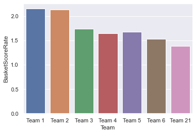

```python
new_plt = sb.barplot(x="Team", y="BasketScoreRate",  data=data_basscored)
```

- Team1 and Team 2 has a higher basket scored per game

**Team aging**

Considering the TeanLauch year and the winning rate, teams that are very old about 85 years of ageing and above are considered. Records are sort based on the winning rate.

```python
# sort the datframe rows by winning rate
aging_grps_df = part_b_data.sort_values('WinRate', ascending=False)

#reset the index based on new sort values
aging_grps_df.reset_index(inplace=True)

# copy the row index as a column to use that for plotting
aging_grps_df['WinrateIdx'] = aging_grps_df.index
aging_grps_df['WinrateIdx'] = aging_grps_df['WinrateIdx'] + 1

#Calculate the aging value from Team Lauch year value
aging_grps_df['aging'] = aging_grps_df.apply(lambda row: (2022-row.TeamLaunch), axis=1)

#filter the records to find the teams that are older than 85years
aging_grps_df1 = aging_grps_df[aging_grps_df['aging'] > 85 ]
```

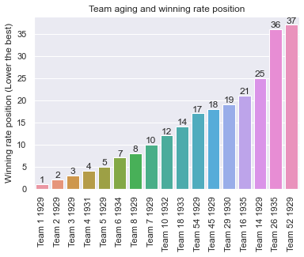

```python
#set the parameters for plotting the graph
sb.set()
plt.figure()

plt_ax = sb.barplot(data=aging_grps_df1, x='Team', y='WinrateIdx')

#set labels
plt_ax.set_title('Team aging and winning rate position')
plt_ax.set_ylabel(('Winning rate position (Lower the best)'))
plt_ax.set_xlabel(None)
#set the x axis paremeter label value by combining Team name and year it was lauched
plt_ax.set_xticklabels(aging_grps_df1['Team']+' '+aging_grps_df1['TeamLaunch'].astype(str), rotation='vertical')

# display the winning rate values
for i in plt_ax.containers:
    plt_ax.bar_label(i,)

plt.show()
```

- Team 1, One of the oldest team among the ones started in 1929 has performed well

**Poor Performing team**

Comsidering the # of tournaments played or exposure to the tournaments played, the poor performance is identified through the position held in the tournaments. considering a 20 tournaments as a threshold. The data is grouped into two, one that played 20 or more and other played less than 20 tournaments with a min of 5 tournaments

```python
data_min_20_tour_played = part_b_data[ part_b_data [ 'Tournament'] >=  20 ]
```

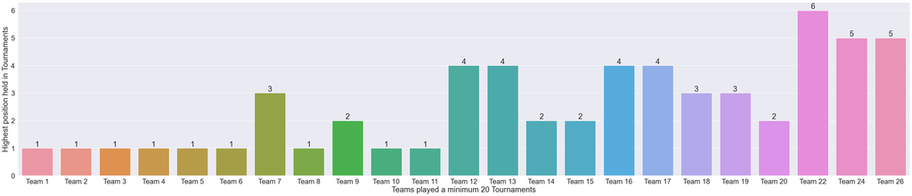

```python
#set the parameters for plotting the graph
sb.set(font_scale=2)
new_plt1 = sb.barplot(x="Team", y="HighestPositionHeld",  data=data_min_20_tour_played)

#set labels
new_plt1.set_ylabel('Highest position held in Tournaments')
new_plt1.set_xlabel('Teams played a minimum 20 Tournaments')

# display the winning rate bar values
for i in new_plt1.containers:
    new_plt1.bar_label(i,)


new_plt1.figure.set_size_inches(50,10)
```

- Team 22 has performed poorly among the teams that played more than 20 tournaments

```python
#filter the teams that played between 5 to 20 tournaments
data_min_5_to_20_tour_played = part_b_data[ (part_b_data [ 'Tournament'] >  5) & (part_b_data [ 'Tournament'] <  20) ]
```

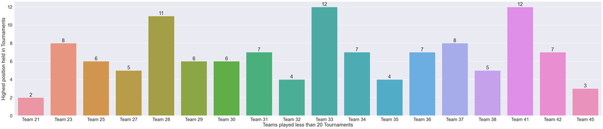

```python
sb.set(font_scale=2)
new_plt2 = sb.barplot(x="Team", y="HighestPositionHeld",  data=data_min_5_to_20_tour_played)

#set labels
new_plt2.set_ylabel('Highest position held in Tournaments')
new_plt2.set_xlabel('Teams played less than 20 Tournaments')

# display the winning rate bar values
for i in new_plt2.containers:
    new_plt2.bar_label(i,)

new_plt2.figure.set_size_inches(50,10)
```

- Team 33 and Team 41 have performed poorly among the teams that has played in 5 to 20 tournaments

# Multivariate Analysis

In MultiVariate analysis we can understand interactions between diferent fields in the dataset

Plot a pair plot to understand the relationship between any given pair of fields

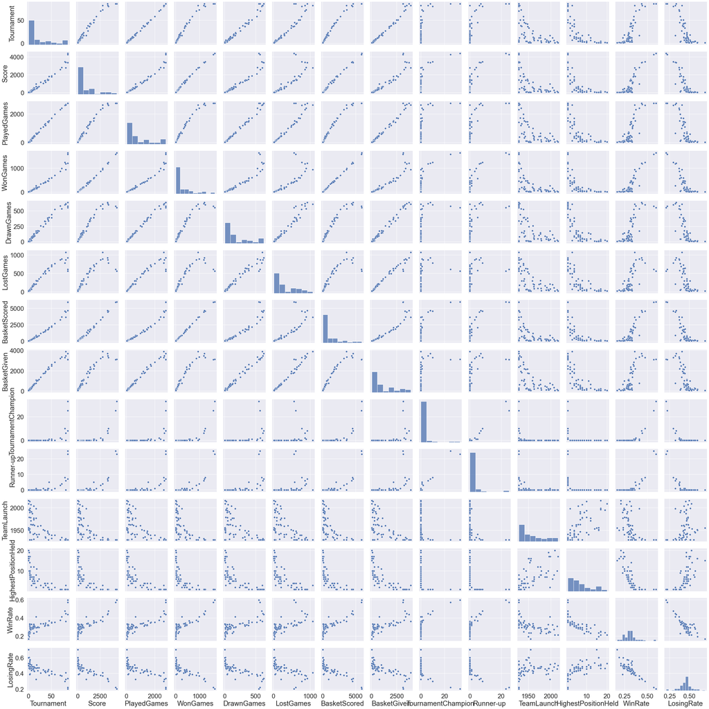

```python
sb.pairplot(part_b_data)
```

Since the above only provides visual information and scales are different based on the values, we use the correlations calculated for the columns to provide a heatmap

```python
part_b_data.corr() # display the correlation between every possible pairs column data in the dataframe
```

|  | Tournament | Score | PlayedGames | WonGames | DrawnGames | LostGames | BasketScored | BasketGiven | TournamentChampion | Runner-up | TeamLaunch | HighestPositionHeld | WinRate | LosingRate |
| --- | --- | --- | --- | --- | --- | --- | --- | --- | --- | --- | --- | --- | --- | --- |
| Tournament | 1.000000 | 0.981258 | 0.998683 | 0.971749 | 0.989295 | 0.949350 | 0.974867 | 0.987781 | 0.589304 | 0.645924 | -0.599166 | -0.708002 | 0.819545 | -0.761262 |
| Score | 0.981258 | 1.000000 | 0.979687 | 0.997232 | 0.958090 | 0.878780 | 0.996634 | 0.943801 | 0.715014 | 0.764819 | -0.538542 | -0.669215 | 0.877374 | -0.809545 |
| PlayedGames | 0.998683 | 0.979687 | 1.000000 | 0.967486 | 0.993972 | 0.955925 | 0.969970 | 0.990020 | 0.575072 | 0.633101 | -0.581243 | -0.711065 | 0.813167 | -0.767881 |
| WonGames | 0.971749 | 0.997232 | 0.967486 | 1.000000 | 0.939416 | 0.851436 | 0.999312 | 0.925745 | 0.752904 | 0.797849 | -0.540421 | -0.647819 | 0.884266 | -0.802802 |
| DrawnGames | 0.989295 | 0.958090 | 0.993972 | 0.939416 | 1.000000 | 0.972786 | 0.942234 | 0.992479 | 0.503378 | 0.566021 | -0.570175 | -0.720248 | 0.774409 | -0.757428 |
| LostGames | 0.949350 | 0.878780 | 0.955925 | 0.851436 | 0.972786 | 1.000000 | 0.857843 | 0.985041 | 0.324025 | 0.391645 | -0.591571 | -0.726172 | 0.665352 | -0.655008 |
| BasketScored | 0.974867 | 0.996634 | 0.969970 | 0.999312 | 0.942234 | 0.857843 | 1.000000 | 0.931079 | 0.743847 | 0.791041 | -0.550150 | -0.648672 | 0.879110 | -0.795022 |
| BasketGiven | 0.987781 | 0.943801 | 0.990020 | 0.925745 | 0.992479 | 0.985041 | 0.931079 | 1.000000 | 0.471618 | 0.533448 | -0.608902 | -0.727323 | 0.757267 | -0.717052 |
| TournamentChampion | 0.589304 | 0.715014 | 0.575072 | 0.752904 | 0.503378 | 0.324025 | 0.743847 | 0.471618 | 1.000000 | 0.971533 | -0.286768 | -0.304307 | 0.765329 | -0.638620 |
| Runner-up | 0.645924 | 0.764819 | 0.633101 | 0.797849 | 0.566021 | 0.391645 | 0.791041 | 0.533448 | 0.971533 | 1.000000 | -0.317250 | -0.359191 | 0.801226 | -0.677157 |
| TeamLaunch | -0.599166 | -0.538542 | -0.581243 | -0.540421 | -0.570175 | -0.591571 | -0.550150 | -0.608902 | -0.286768 | -0.317250 | 1.000000 | 0.599679 | -0.491244 | 0.201703 |
| HighestPositionHeld | -0.708002 | -0.669215 | -0.711065 | -0.647819 | -0.720248 | -0.726172 | -0.648672 | -0.727323 | -0.304307 | -0.359191 | 0.599679 | 1.000000 | -0.737345 | 0.661343 |
| WinRate | 0.819545 | 0.877374 | 0.813167 | 0.884266 | 0.774409 | 0.665352 | 0.879110 | 0.757267 | 0.765329 | 0.801226 | -0.491244 | -0.737345 | 1.000000 | -0.851445 |
| LosingRate | -0.761262 | -0.809545 | -0.767881 | -0.802802 | -0.757428 | -0.655008 | -0.795022 | -0.717052 | -0.638620 | -0.677157 | 0.201703 | 0.661343 | -0.851445 | 1.000000 |

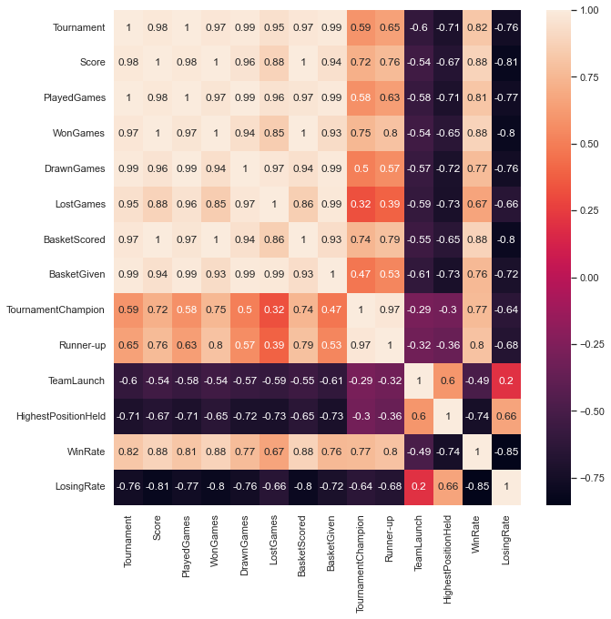

```python
#Representing the correlations in aheatmap to understand the significance of the columns
sb.set(font_scale=1)
sb.set(rc={"figure.figsize":(10, 10)})
sb.heatmap(part_b_data.corr(), annot=True)
```

**Answer 2 (Part B)**

**Summary**

Tournament Winner and runnerup

- *Team 1 has won more tournaments compared to Team 2 and Team 5*
- *Team 2 has been runnerup more times than Team 1 and Team 5*

Games Winning Streak

- *Team 1 has a higher winning streak

Basket Scored

- *Team1 and Team 2 has a higher basket scoring rate per game

Team aging

- *Team 1, One of the oldest team among the ones started in 1929 has performed well

Poor Performing team

- *Team 22 has performed poorly among the teams that played more than 20 tournaments
- *Team 33 and Team 41 have performed poorly among the teams that has played in 5 to 20 tournaments

**Recommendation**

Alternatively Team 2 also has a good performance and can be considered if deal with Team 1 does not materalize

-Team 1 is the best performing oldest team.

-Team 22, Team 33 and Team 41 have performed poorly among their peers

**Q 3**

Please include any improvements or suggestions to the association management on quality, quantity, variety, velocity, veracity etc. on the data points collected by the association to perform a better data analysis in future

**Quality**

Resources are spent a lot in searching for and preparing data to deliver insights. Completeness, Accuracy, Consistency, Validity and Integrity are some of the best attributes that define quality of data. The team details miss the players performance, demographic details, market value of the team. And how many games they have played/won/lost in home ground and other places. Size of the team and cost to maintain the team etc.

**Quantity or Volume**

The volume of data refers to the size of the data sets that need to be analyzed and processed, which are now larger. The sheer volume of the data is required to improve analysis and prediction. Here the the volume of the data is limited to 60 teams and not much detailed information is available. More information is required to recommend a better team to Company X

**Variety**

Data variety refers to the way data is collected across an organization–in different formats, across different business units, and with differing organizational structures. ML aids enterprise to manage the mapping, integration and transformation of many datasets into a common data model, all in a scalable way.  
Team details can be enhanced with other variety of data like

- turf played,
- weather,
- commercial value of games etc.
- Social media details can be included in the team details on the fan base size or
- subscribers to the team fan pages.
- Team's approval ratings across the matches can be included

**Velocity**

Velocity is the speed at which the data is collected and processed. Unlike earlier , machines help to process huge data in a quicker manner. Data can be collected in Real-time, batch process, feeds, user or machine trigerred data collection etc.

**Veracity**

Structured data is data that is generally well organized and it can be easily analyzed by a machine or by humans. Data can only be used meaningfully and sustainably if it is reliable. If the data quality is questionable or unclear how the data was generated, it cannot be used reliably for analysis. The played Games vs Basket scored provides a mean of 1.7 baskets per match per team. This column data needs improvement The TeamLauch year variable column data has single year, year range etc and needs a cleanup or valid data

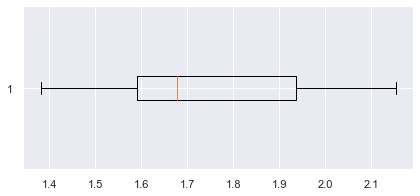

```python
f = plt.figure()
f.set_figwidth(7)
f.set_figheight(3)
plt.boxplot(data_basscored['BasketScoreRate'], vert=0)

plt.show()
```

```python
print(data_basscored['BasketScoreRate'].describe())
```

```
count    7.000000
mean     1.751471
std      0.292257
min      1.380800
25%      1.589550
50%      1.676700
75%      1.935300
max      2.153100
Name: BasketScoreRate, dtype: float64
```

## Part C

Company X is a EU online publisher focusing on the startups industry. The company specifically reports on the business related to technology news, analysis of emerging trends and profiling of new tech businesses and products. Their event i.e. Startup Battlefield is the world’s pre-eminent startup competition. Startup Battlefield features 15-30 top early stage startups pitching top judges in front of a vast live audience, present in person and online.

**Q 1.**

Read the CSV file.

```python
# Use Pandas to read the csv data into a dataframe
part_c_data = pd.read_csv('AnalyticsProject\DS_Part3_CompanyX_EU.csv')
```

**Q 2.**

Data Exploration: A. Check the datatypes of each attribute.

```python
part_c_data.dtypes
```

```
Startup           object
Product           object
Funding           object
Event             object
Result            object
OperatingState    object
dtype: object
```

**Answer 2A :** Data type is listed above, all the data types are object as columns have charaters and others have numeric and null

**Q 2.**

Data Exploration: B. Check for null values in the attributes

```python
part_c_data.isnull().sum()
```

```
Startup             0
Product             6
Funding           214
Event               0
Result              0
OperatingState      0
dtype: int64
```

**Answer 2 B :** Column Funding and Product has null values

**Q 3.** Data preprocessing & visualisation:

**Q 3A** Drop the null values.

```python
# drop rows that has null values
part_c_data_nonull = part_c_data.dropna().copy(deep=True)
```

```python
part_c_data_nonull.head
```

```
<bound method NDFrame.head of           Startup          Product Funding                      Event  \
1            3DLT         3dlt.com   $630K           Disrupt NYC 2013
3      3Dprintler   3dprintler.com     $1M            Disrupt NY 2016
5            5to1         5to1.com  $19.3M                  TC50 2009
6    8 Securities  8securities.com    $29M       Disrupt Beijing 2011
10     AdhereTech   adheretech.com   $1.8M  Hardware Battlefield 2014
..            ...              ...     ...                        ...
657        Zivity       zivity.com     $8M                  TC40 2007
658        Zmorph     zmorph3d.com     $1M                          -
659        Zocdoc       zocdoc.com   $223M                  TC40 2007
660          Zula      zulaapp.com   $3.4M            Disrupt SF 2013
661        Zumper       zumper.com  $31.5M            Disrupt SF 2012

              Result OperatingState
1         Contestant         Closed
3    Audience choice      Operating
5         Contestant       Acquired
6           Finalist      Operating
10        Contestant      Operating
..               ...            ...
657       Contestant      Operating
658  Audience choice      Operating
659       Contestant      Operating
660  Audience choice      Operating
661         Finalist      Operating

[446 rows x 6 columns]>
```

```python
part_c_data_nonull.isnull().sum()
```

```
Startup           0
Product           0
Funding           0
Event             0
Result            0
OperatingState    0
dtype: int64
```

**Answer 3A :** All null values are removed.

**Q 3B.** Convert the ‘Funding’ features to a numerical value.

```python
# convert funding values to numeric based on last character
part_c_data_nonull.loc[:,'Funds_in_million'] = part_c_data_nonull['Funding'].apply(lambda x: float(x[1:-1])/1000 if x[-1] == 'K' else (float(x[1:-1])*1000 if x[-1] == 'B' else float(x[1:-1])))
```

```python
# Check the newly added column
part_c_data_nonull.describe()
```

|  | Funds_in_million |
| --- | --- |
| count | 446.000000 |
| mean | 17.241489 |
| std | 90.483710 |
| min | 0.005000 |
| 25% | 0.745250 |
| 50% | 2.200000 |
| 75% | 9.475000 |
| max | 1700.000000 |

**Answer 3B :** Funding column values are converted to numeric and set into a new "Funds_in_million" column

**Q 3C.** Plot box plot for funds in million.

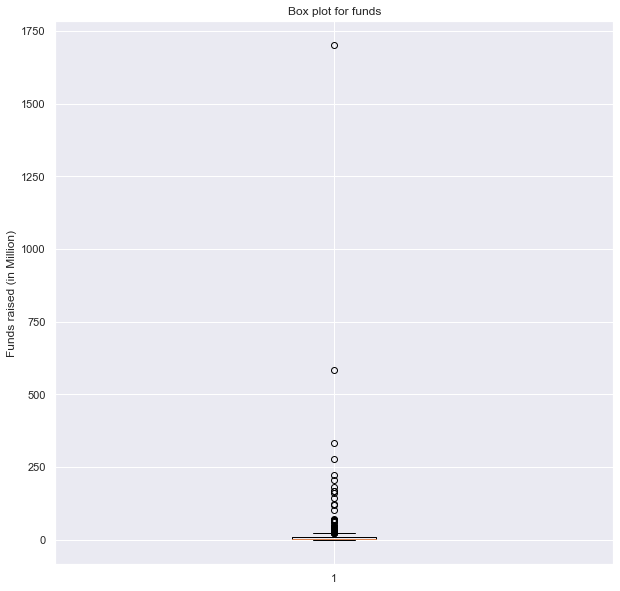

```python
# Load the box plot inputs
c_plot = plt.boxplot( part_c_data_nonull.Funds_in_million )
plt.title( "Box plot for funds" )
plt.ylabel( "Funds raised (in Million)" )

plt.show()
```

**Q 3D**</br> D. Check the number of outliers greater than the upper fence.

```python
upper_fence_outliers = c_plot['caps'][1].get_data()[1][1]
```

```python
outlrs_grtr_upprFen = len( part_c_data_nonull[ part_c_data_nonull.Funds_in_million > upper_fence_outliers ] )
print( color.BOLD +'Answer 3D'+color.END+':  Number of outliers greater than the upper fence is {:.0f}'.format(outlrs_grtr_upprFen))
```

```
Answer 3D:  Number of outliers greater than the upper fence is 60
```

**Q 3E** Check frequency of the OperatingState features classes.

```python
val_count = part_c_data_nonull.groupby(['OperatingState']).size()
print(val_count)
```

```
OperatingState
Acquired      66
Closed        57
Ipo            4
Operating    319
dtype: int64
```

**Answer 3E** : The Frequency of OperatingState feature values are provided above

**Q 4. Statistical Analysis:** </br> **Q 4A.** Is there any significant difference between Funds raised by companies that are still operating vs companies that closed down?

Remove the outliers to prepare for a better comparision

```python
part_c_data_wo_outlier = part_c_data_nonull.drop( part_c_data_nonull[ part_c_data_nonull.Funds_in_million > upper_fence_outliers ].index, inplace = False)
```

```python
part_c_data_wo_outlier.OperatingState.value_counts()
```

```
Operating    275
Closed        56
Acquired      55
Name: OperatingState, dtype: int64
```

Compare the Funds raised by companies that are operating (275 Nos) against the ones that are closed (56 Nos)

Distribution of funds by all companies Operating, Closed and Aquired

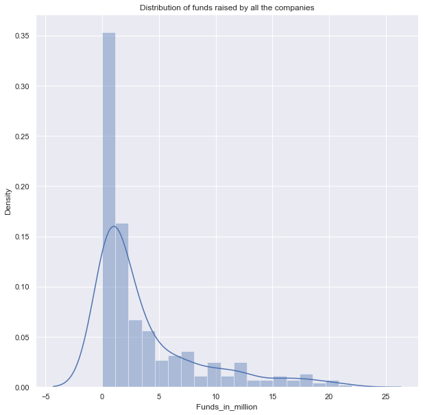

```python
# populate the plot with inputs from data without outliers
sb.distplot( part_c_data_wo_outlier.Funds_in_million)
plt.title('Distribution of funds raised by all the companies')
plt.show()
```

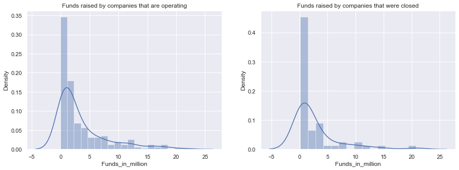

```python
# Set the inputs for populating two plots one each for companies that are operating and other for closed ones.
plotfig, plot_ax = plt.subplots( 1, 2 )

plotfig.set_figheight(5)
plotfig.set_figwidth(15)

sb.distplot( part_c_data_wo_outlier.loc[part_c_data_wo_outlier.OperatingState == 'Operating', 'Funds_in_million'], ax = plot_ax[0] )
sb.distplot( part_c_data_wo_outlier.loc[part_c_data_wo_outlier.OperatingState == 'Closed', 'Funds_in_million'], ax = plot_ax[1] )

plot_ax[0].set_title('Funds raised by companies that are operating')
plot_ax[1].set_title('Funds raised by companies that were closed')
```

- Both the distributions are simillar
- Hypothesis test is required to prove there is difference
- Can use sample t test and z test to compare the difference

**Q 4B.** Write the null hypothesis and alternative hypothesis.

**Ans 4B**

**Null Hypothesis (Ho)** : There is no difference between funds sourced by operating and closed companies</br> **Alternate Hypothesis (Ha)** : There is a significant difference between funds sourced by operating and closed companies

**Q 4C.** Test for significance and conclusion

```python
# import Z test and t test libraries
from statsmodels.stats.weightstats import ztest
from scipy.stats import ttest_ind
```

```python
# Create samples from operating companies and from closed companies
opertng_sample = part_c_data_wo_outlier.loc[ part_c_data_wo_outlier.OperatingState == 'Operating', 'Funds_in_million' ]
clsd_sample    = part_c_data_wo_outlier.loc[ part_c_data_wo_outlier.OperatingState == 'Closed', 'Funds_in_million' ]

#consider a 0.05 or 5% significance levels to validate the hypothesis
alpha_consrd = 0.05

#Execute the Z test using 2 samples created
ztest_statistics, z_p_value = ztest( opertng_sample, clsd_sample )

if z_p_value <= alpha_consrd :
    print(f'As the p-value from ztest, { round( z_p_value, 3 ) } <  { alpha_consrd } alpha value, there is significant difference between funds sourced by operating & closed  companies, hence the Null Hypothesis is rejected')
else :
    print(f'As the p-value from ztest, { round( z_p_value, 3 ) } >  { alpha_consrd } alpha value, there is NO significant difference between funds sourced by operating & closed  companies, hence FAIL to reject the Null Hypothesis')
```

```
As the p-value from ztest, 0.192 >  0.05 alpha value, there is NO significant difference between funds sourced by operating & closed  companies, hence FAIL to reject the Null Hypothesis
```

```python
#Execute the t test using 2 samples created
ttest_statistics, t_p_value = ttest_ind( opertng_sample, clsd_sample )

if t_p_value <= alpha_consrd :
    print(f'As the p-value from ztest, { round( t_p_value, 3 ) } <  { alpha_consrd } alpha value, there is significant difference between funds sourced by operating & closed  companies, hence the Null Hypothesis is rejected')
else :
    print(f'As the p-value from ztest, { round( t_p_value, 3 ) } >  { alpha_consrd } alpha value, there is NO significant difference between funds sourced by operating & closed  companies, hence FAIL to reject the Null Hypothesis')
```

```
As the p-value from ztest, 0.193 >  0.05 alpha value, there is NO significant difference between funds sourced by operating & closed  companies, hence FAIL to reject the Null Hypothesis
```

**Answer 4C.** From the Z test and t test it is concluded that there is NO significant difference between funds sourced by operating & closed companies, hence **FAIL to reject the Null Hypothesis**

**Q 4D.** Make a copy of the original data frame.

**Ans 4D :** Create a Copy the Dataframe loaded from CSV file using copy function

```python
# create a copy of the  dataframe orginally load from data file
part_c_data_copy = part_c_data.copy(deep = True)
```

**Q 4E** Check frequency distribution of Result variables

**Ans 4E:** Display the 'Result' column values by grouping them

```python
part_c_data_copy.Result.value_counts()
```

```
Contestant         488
Finalist            84
Audience choice     41
Winner              26
Runner up           23
Name: Result, dtype: int64
```

**Q 4F** Calculate percentage of winners that are still operating and percentage of contestants that are still operating

**Ans 4F :** Calculate the values of individual and cumulative values and arrive at percentage

```python
qualified_contestants = part_c_data_copy.Result.value_counts()[1:].sum()
winners               = part_c_data_copy.Result.value_counts()['Winner']
contestants           = part_c_data_copy.Result.value_counts()['Contestant']
```

```python
qualified_cont_oprtng = part_c_data_copy.OperatingState[ part_c_data_copy.Result != 'Contestant'].value_counts().loc['Operating']
contestants_oprtng = part_c_data_copy.OperatingState[ part_c_data_copy.Result == 'Contestant'].value_counts().loc['Operating']
winners_oprtng = part_c_data_copy.OperatingState[ part_c_data_copy.Result == 'Winner'].value_counts().loc['Operating']
```

```python
winners_oprtng / winners,  qualified_cont_oprtng /qualified_contestants, contestants_oprtng / contestants
```

```
(0.7307692307692307, 0.764367816091954, 0.680327868852459)
```

```python
print(color.BOLD + 'Answer 4F'+  color.END)
print('Percentage of Winners that are still operating is {:.2f}%'.format( ( winners_oprtng / winners)*100 ) )
print('Percentage of contestants that are still operating is {:.2f}%'.format( ( contestants_oprtng / contestants )*100 ) )
print('Percentage of Qualified contestants including winnners, awardeees, finalists that are still operating is {:.2f}%'.format( ( qualified_cont_oprtng /qualified_contestants )*100 ) )
```

```
Answer 4F
Percentage of Winners that are still operating is 73.08%
Percentage of contestants that are still operating is 68.03%
Percentage of Qualified contestants including winnners, awardeees, finalists that are still operating is 76.44%
```

**Q 4G** Write your hypothesis comparing the proportion of companies that are operating between winners and contestants:

**Ans 4G.**

**Null Hypothesis (Ho)** : the proportion of companies that are operating between winners and contestants is same in both categories</br> **Alternate Hypothesis (Ha)** : the proportion of companies that are operating between winners and contestants is significtantly different among them

**Q 4H.** Test for significance and conclusion

**Ans 4H.** To test the significance of the proportion between companies operating among winners(qualified contestants) and contestants, Z test for proportions can be used

```python
# load z test for proportions libraries
from statsmodels.stats.proportion import proportions_ztest
```

```python
#consider a 0.05 or 5% significance levels to validate the hypothesis and it is already declared earlier and is used

z_test_p_statistics,  z_prop_p_value = proportions_ztest( [ contestants_oprtng, qualified_cont_oprtng], [ contestants, qualified_contestants ] )

if z_prop_p_value <= alpha_consrd :
    print(f'As the p-value from ztest, { round( z_prop_p_value, 3 ) } <  { alpha_consrd } alpha value, there is significant difference between proportions, hence the Null Hypothesis is rejected')
else :
    print(f'As the p-value from ztest, { round( z_prop_p_value, 3 ) } >  { alpha_consrd } alpha value, there is NO significant difference proportions, hence FAIL to reject the Null Hypothesis')
```

```
As the p-value from ztest, 0.037 <  0.05 alpha value, there is significant difference between proportions, hence the Null Hypothesis is rejected
```

**Q 4I** Select only the Event that has ‘disrupt’ keyword from 2013 onwards

**Answer 4I**

```python
# Choosing orginal data loaded from csv file
disrupt_event_from_2013 = part_c_data[ part_c_data.Event.apply(lambda x: 'Disrupt' in x and int( x[-4:] ) > 2012 ) ].Event
print(color.BOLD + 'Answer 4I' + color.END)
print(disrupt_event_from_2013)
```

```
Answer 4I
0          Disrupt SF 2013
1         Disrupt NYC 2013
2          Disrupt SF 2016
3          Disrupt NY 2016
4         Disrupt NYC 2013
              ...
646    Disrupt London 2015
648    Disrupt London 2015
653        Disrupt EU 2014
656       Disrupt NYC 2013
660        Disrupt SF 2013
Name: Event, Length: 276, dtype: object
```

```python
# Choosing filtered data without outliers and without null funding values
disrupt_event_from_2013_sub = part_c_data_wo_outlier[ part_c_data_wo_outlier.Event.apply(lambda x: 'Disrupt' in x and int( x[-4:] ) > 2012 ) ].Event
print(color.BOLD + 'Answer 4I' + color.END)
print(disrupt_event_from_2013_sub)
```

```
Answer 4I
1         Disrupt NYC 2013
3          Disrupt NY 2016
13         Disrupt SF 2015
14     Disrupt London 2016
16         Disrupt SF 2015
              ...
635        Disrupt NY 2015
641       Disrupt NYC 2013
642        Disrupt SF 2014
646    Disrupt London 2015
660        Disrupt SF 2013
Name: Event, Length: 185, dtype: object
```

The Events that has keyword are 'Disrupt' and year 2013 onwards are filtered and listed above